# Project_1: Site Creation

## Step 1

- I used a Jekyll Theme, many free ones can be found here:

https://jekyllthemes.io/github-pages-themes

> Note: The pages for many of the themes are in html.

## Step 2

- All the (free) themes have a `Get ____ on Github`. **(blue)**
  - Click this and it will take you to the theme Github page.

[figure not shown]

2.1

## Step 3

- Once on the theme Github page look for the readme file. `3.1` **(green)**:
  - In the readme, look for the **github** installation section. `3.2` **(green)**
    - Here, the instructions are shown (fork and create a gh-pages branch). `3.2` **(light blue)**

> *Note* different themes may have different specific parameters (as found in the respective readme)

[figure not shown]

3.1

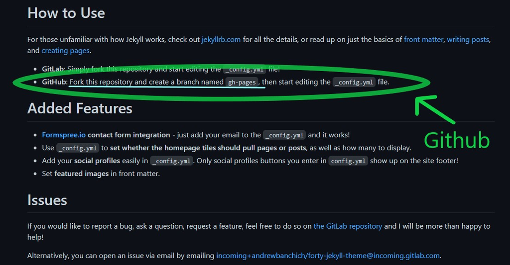

3.2

## Step 4

- After you have read the readme, go back to the repository page. `4.1`
  - This time, click the fork icon in the upper right corner. This creates a clone of the repo in your github. `4.1` **(red)**
    - If forked successfully, you will see the new “forked” repo on your homepage. Mine is displayed here in both recent and the front page. `4.2` **(orange)** and **(light blue)**

[figure not shown]

4.1

[figure not shown]

4.2

## Step 5

- Click on the new “forked” repository.
  - The readme said a new branch called `gh-pages` is needed for this theme:
    1. Click branches. `5.1` **(red)**
    2. Input gh-pages into the drop down prompt. `5.1` **(purple)**
    3. Create new branch. `5.1` **yellow**

> Note: Some forks come with gh-pages (or whichever branch) already included.

[figure not shown]

5.1

## Step 6

- On the new `gh-pages` branch, there should be two important files:
  1. The _config.yml. `6.1` **brown**
     - This may have important wholesale quick-edit applications, depending on your theme.
  2. The index.html (which is the homepage). `6.1` **red**
     - This executes similarly to the default index.html for the course.
     - Github reads and launches this as your homepage for the repository.
     - Changes made here will change the homepage.

[figure not shown]

6.1

## Step 7

- In image `7.1` I have pulled my repo from github into R and am on my own index.html page.
  - Make sure you are in the correct branch (gh-pages, in this case).
    - `git checkout` in the R Studio terminal will allow you to select the branch.
      - For example, here it would be `git checkout gh-pages`.
- I have circled a section of my index.html `7.1` **green**
  - The `href="/ForcadeBio381/homework.html"` is a html hyperlink attached to an image `<img src="onehouse.jpg"` on my index.
    - Editing the `href` will change the hyperlink output, so you can forward to further .html pages you create.
    - Editing the `<img/>` will change the picture.

> Note: Assets (pictures, gifs, .html) you want to use (and reference/call) should be uploaded into the respository (`git push`)

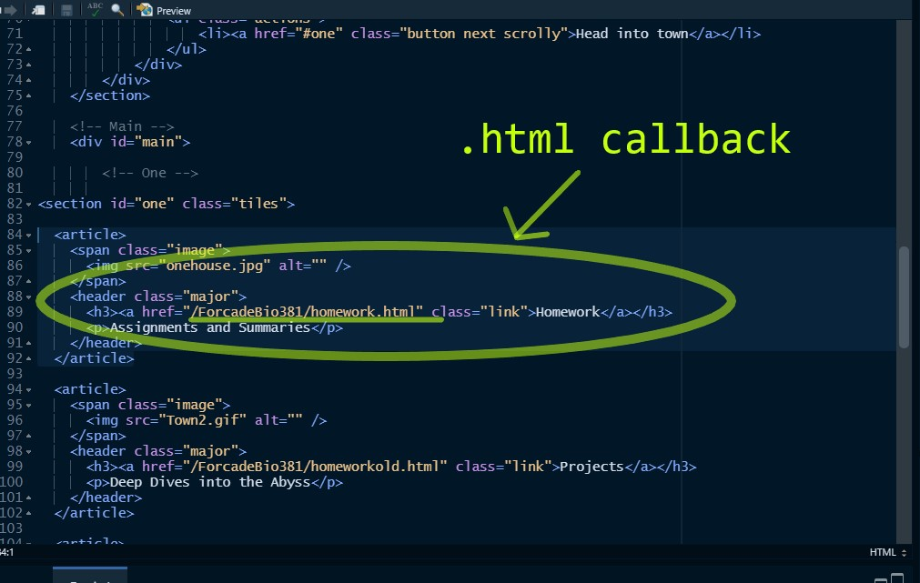

7.1

## Step 7: Example:

- `E.1` is an example of a plain rmarkdown for Homework 3 that is included on my repo. **(orange)**
  - I knit Homework3plain.rmd into Homework3plain.html in R Studio.
  - I then made sure both folders were in the correct branch (`gh-pages`) and ran a `git push` sequence.
- From here, I just need to change `href="/ForcadeBio381/homework.html"` shown in Step 7 into `href="/ForcadeBio381/Homework3plain.html"` to have Homework3plain.html linked instead.

[figure not shown]

E.1

## Reminder: Change Source!

- Make sure to change the display branch in the repository to the created branch.
  - Go to settings in the upper right of your repository. `R.1` **(pink)**
  - In settings, scroll down to change `Source` to `gh-pages`. `R.2` **(light blue)**

[figure not shown]

R.1

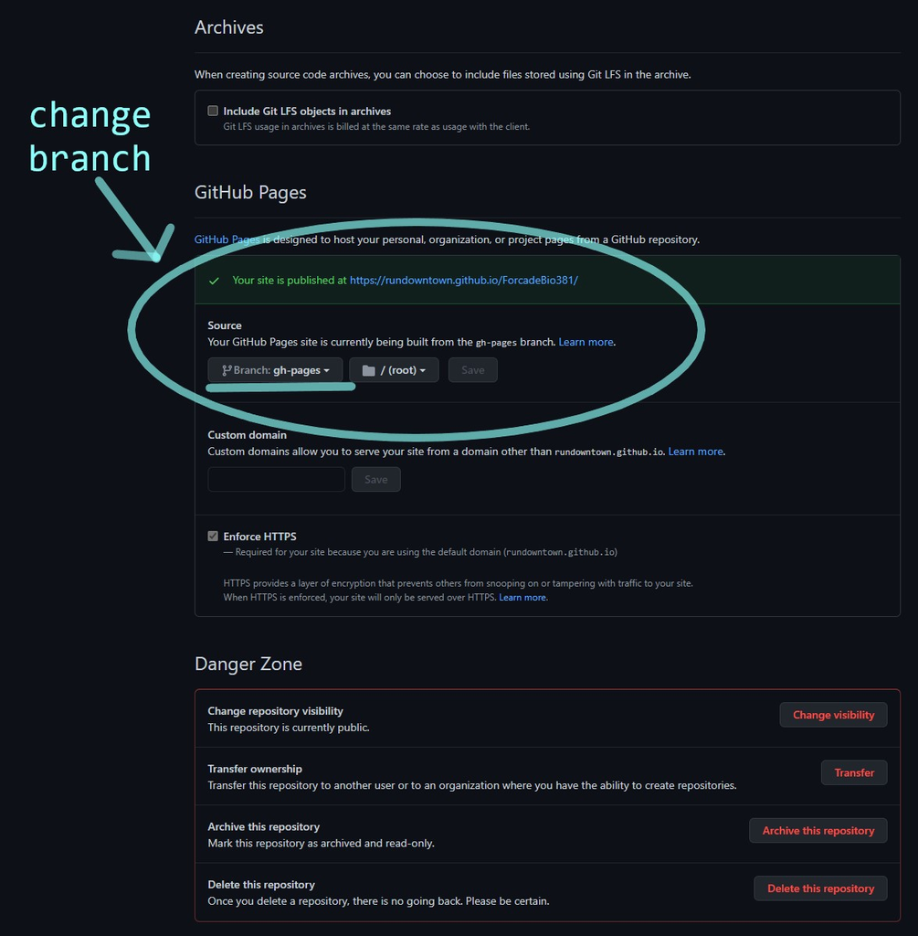

R.2